# 1111classPLOSautismbiomarkers

Kaitlyn Westra

11/11/2020

```r
library(tidyverse)
library(tidymodels)
library(ggridges)
```

```r
data_filename <- "data/autism.csv"
if (!file.exists(data_filename)) {
  dir.create("data")
  download.file("https://doi.org/10.1371/journal.pcbi.1005385.s001", data_filename)
}
col_names <- names(read_csv(data_filename, n_max = 1, col_types = cols(.default = col_character())))
autism <- read_csv(data_filename, skip = 2, col_names = col_names, col_types = cols(
  .default = col_double(),
  Group = col_character()
)) %>% mutate(
  Group = as_factor(Group)
)
```

```r
autism %>% select(-1, -last_col())
```

```
## # A tibble: 206 x 24
##    Methion.   SAM   SAH `SAM/SAH` `% DNA methylat… `8-OHG` Adenosine
##       <dbl> <dbl> <dbl>     <dbl>            <dbl>   <dbl>     <dbl>
##  1     17.3  56.2 15.2       3.69             3.35   0.055     0.103
##  2     14.9  37.2  7.58      4.91             3.04   0.045     0.055
##  3     15.9  37.9  9.87      3.84             2.81   0.058     0.071
##  4     18.7  79.2 24.5       3.23             4.24   0.085     0.079
##  5     21.5  77.6 19.2       4.04             3.49   0.041     0.058
##  6     18.1  67.6 12.8       5.30             3.01   0.156     0.091
##  7     27.5  60.6 19.6       3.10             3.19   0.072     0.248
##  8     29.8  41.4  9.64      4.29             2.77   0.053     0.113
##  9     13.4  61.6  9.17      6.72             3.01   0.068     0.045
## 10     21.6  47.5 26.5       1.80             3.56   0.069     0.146
## # … with 196 more rows, and 17 more variables: Homocysteine <dbl>,
## #   Cysteine <dbl>, `Glu.-Cys.` <dbl>, `Cys.-Gly.` <dbl>, tGSH <dbl>,
## #   fGSH <dbl>, GSSG <dbl>, `fGSH/GSSG` <dbl>, `tGSH/GSSG` <dbl>,
## #   Chlorotyrosine <dbl>, Nitrotyrosine <dbl>, Tyrosine <dbl>,
## #   Tryptophane <dbl>, fCystine <dbl>, fCysteine <dbl>,
## #   `fCystine/fCysteine` <dbl>, `% oxidized` <dbl>
```

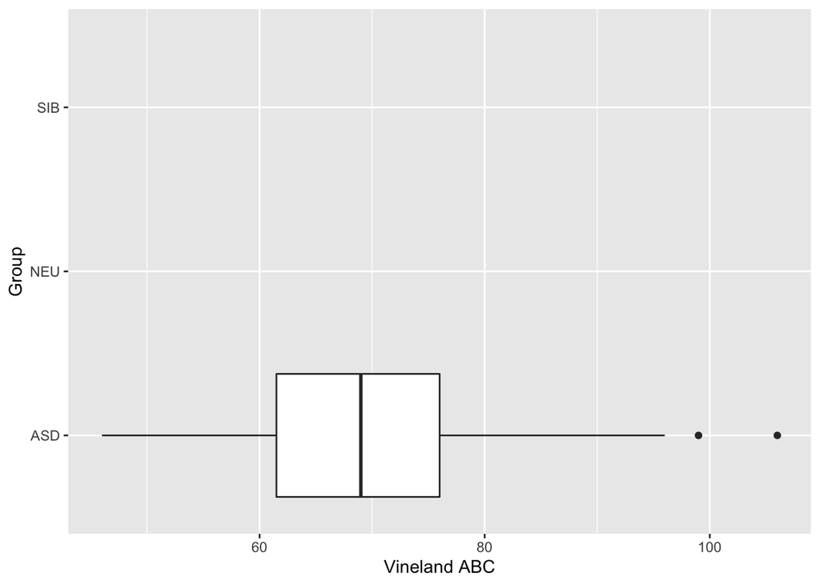

```r
#life skills, for ASD children
autism %>%
  ggplot(aes(x = `Vineland ABC`, y = Group)) + geom_boxplot()
```

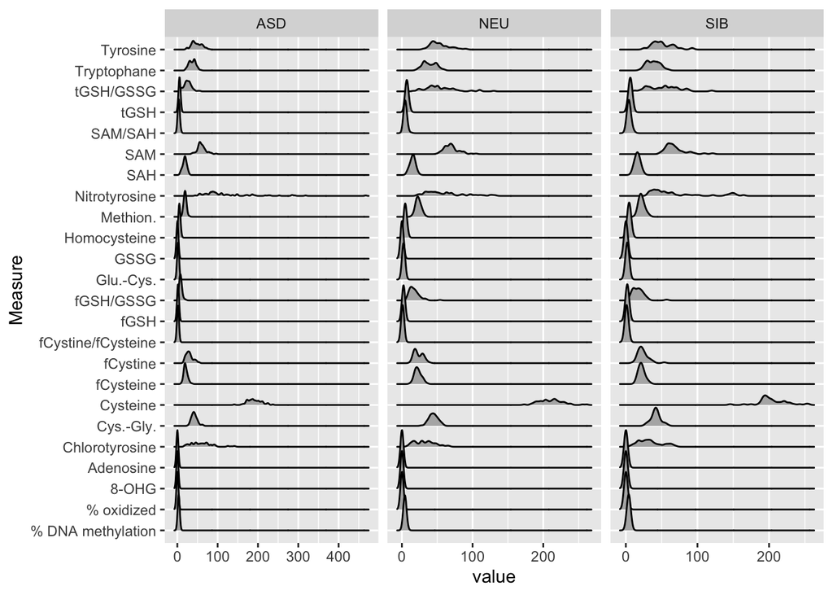

```r
autism %>%
  select(-`Vineland ABC`) %>%
  pivot_longer(-Group, names_to = "Measure") %>%
  ggplot(aes(x = value, y = Measure)) +
  geom_density_ridges() +
  facet_wrap(vars(Group), scales = "free_x")
```

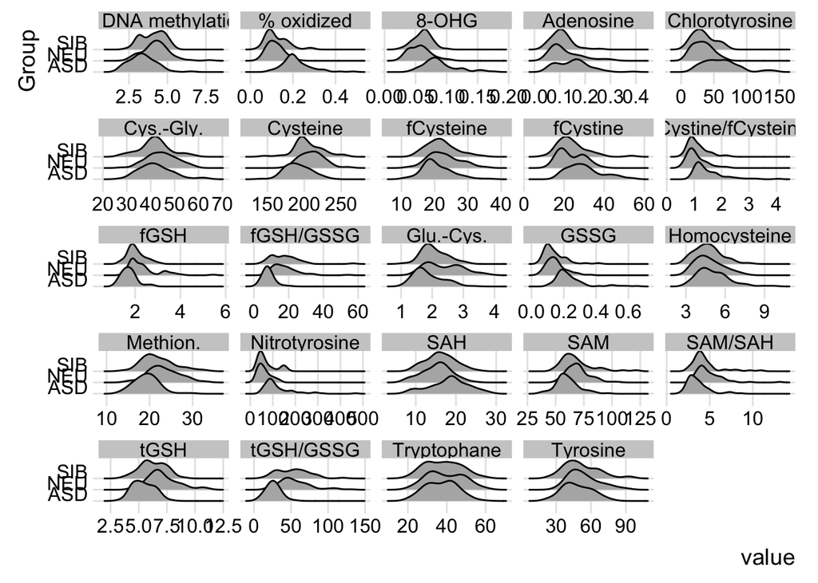

```r
autism %>%
  select(-`Vineland ABC`) %>%
  pivot_longer(-Group, names_to = "Measure") %>%
  ggplot(aes(x = value, y = Group)) +
  geom_density_ridges() +
  facet_wrap(vars(Measure), scales = "free_x") +
  theme_ridges()
```

% oxidized seems to be higher for ASD. Maybe a cutoff @ 0.15 would be useful here to predict. Maybe a decision tree could cut here.

Let's start by (1) ignoring the behavior scores (that's an outcome) and comparing just ASD and NEU.  
We need to drop SIB... and tell the model that we don't actually care about it.

```r
data <-
  autism %>%
  select(-`Vineland ABC`) %>%
  filter(Group != "SIB") %>%
  mutate(Group = factor(Group))
```

```r
spec <- workflow() %>% add_recipe(
  recipe(Group ~ ., data = data)) %>%
  add_model(decision_tree(mode = "classification") %>% set_engine("rpart"))
model <- spec %>% fit(data)
```

```r
model %>% predict(data, type = "prob")
```

```
## # A tibble: 159 x 2
##    .pred_ASD .pred_NEU
##        <dbl>     <dbl>
##  1     0.959    0.0411
##  2     0.959    0.0411
##  3     0.959    0.0411
##  4     0.959    0.0411
##  5     0.959    0.0411
##  6     0.959    0.0411
##  7     0.333    0.667
##  8     0.959    0.0411
##  9     0.583    0.417
## 10     0.959    0.0411
## # … with 149 more rows
```

2 cols: how likely they are to have ASD vs NEU. probability.

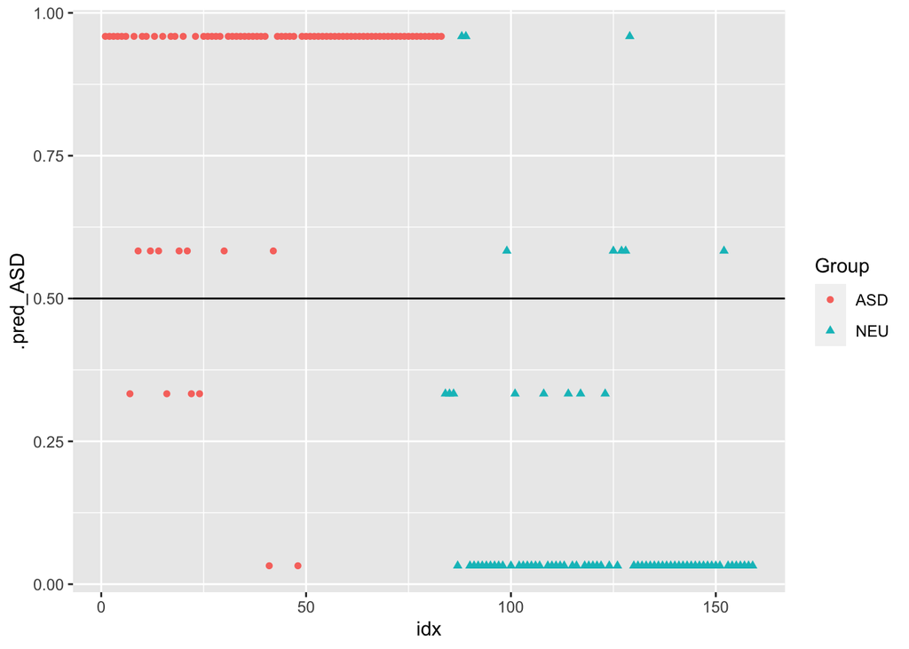

```r
model %>%
  predict(data, type = "prob") %>%
  bind_cols(data) %>%
  mutate(idx = row_number()) %>%
  ggplot(aes(x = idx, y = .pred_ASD, color = Group, shape = Group)) +
  geom_hline(yintercept = .5) +
  geom_point()
```

Looking @ where the model disagrees could tell us more about the disease, too.

Quantifying:

```r
metrics <- yardstick::metric_set(accuracy, sensitivity, specificity)
model %>%
  predict(data, type = "class") %>%
  bind_cols(data) %>%
  metrics(truth = Group, estimate = .pred_class)
```

```
## # A tibble: 3 x 3
##   .metric  .estimator .estimate
##   <chr>    <chr>          <dbl>
## 1 accuracy binary         0.912
## 2 sens     binary         0.928
## 3 spec     binary         0.895
```

```
                   Seizure happened -- No seizure happened
Seizure predicted          TP                     FP
No seizure predicted       FN                     TN
```

Accuracy (% correct) = (TP + TN) / (# episodes) False negative ("miss") rate = FN / (# actual seizures) False positive ("false alarm") rate = FP / (# true non-seizures)

**Sensitivity:** one that predicts autism in almost every autism case. *not missing anyone who does have autism!*

^^ hmmmm not sure about what he was saying here... look it up.

## Logistic Regression

```r
#install.packages("glmnet")
library(glmnet)
spec <- workflow() %>% add_recipe(
  recipe(Group ~ ., data = data)) %>%
  add_model(logistic_reg(penalty = .001) %>% set_engine("glmnet")) #don't worry about these
model <- spec %>% fit(data)
```

Look at the coefficient:

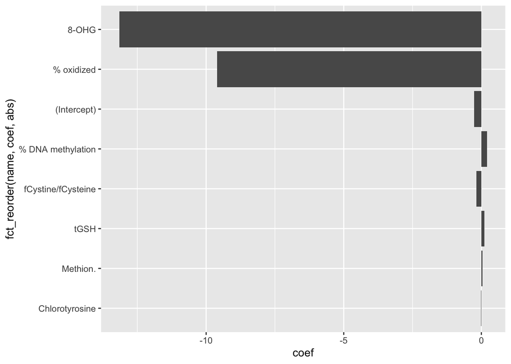

```r
model %>% pull_workflow_fit() %>% pluck('fit') %>% coef(s = .1) %>% as.matrix() %>% as_tibble(rownames = "name") %>%
  rename(coef = 2) %>% filter(abs(coef) > .01) %>%
  ggplot(aes(x = coef, y = fct_reorder(name, coef, abs))) + geom_col()
```

^ these could just be on a different scale... we forgot to normalize / scale these to be comparable. So, we shouldn't look @ the coefficient quite yet.

```r
model %>% predict(data, type = "prob")
```

```
## # A tibble: 159 x 2
##    .pred_ASD    .pred_NEU
##        <dbl>        <dbl>
##  1     0.912 0.0876
##  2     0.999 0.000964
##  3     1.00  0.0000000524
##  4     1.00  0.0000000369
##  5     0.988 0.0124
##  6     1.00  0.0000222
##  7     0.947 0.0531
##  8     1.00  0.0000209
##  9     0.916 0.0837
## 10     1.00  0.0000000257
## # … with 149 more rows
```

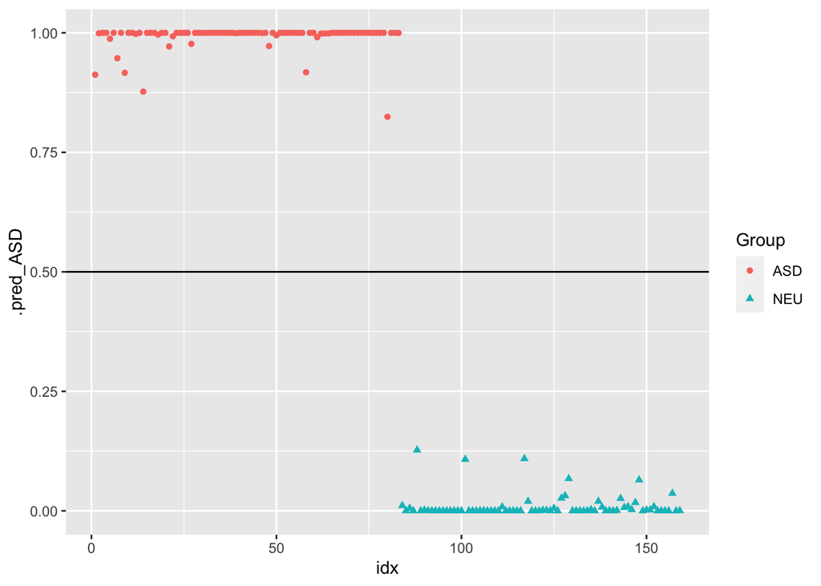

```r
model %>%
  predict(data, type = "prob") %>%
  bind_cols(data) %>%
  mutate(idx = row_number()) %>%
  ggplot(aes(x = idx, y = .pred_ASD, color = Group, shape = Group)) +
  geom_hline(yintercept = .5) +
  geom_point()
```

Should we have validated this? -- YES!

```r
model %>%
  predict(data, type = "class") %>%
  bind_cols(data) %>%
  metrics(truth = Group, estimate = .pred_class)
```

```
## # A tibble: 3 x 3
##   .metric  .estimator .estimate
##   <chr>    <chr>          <dbl>
## 1 accuracy binary             1
## 2 sens     binary             1
## 3 spec     binary             1
```

You can correctly identify this 200 person dataset... so you need cross validation, at least.

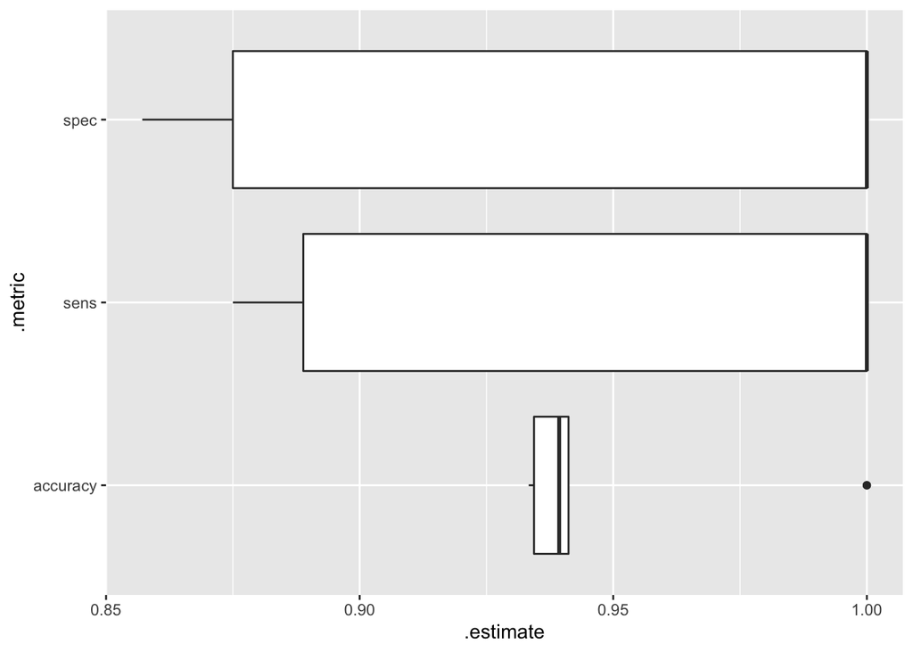

```r
resamples <- data %>% vfold_cv(v = 10, strata = Group)
cv_results <- spec %>%
  fit_resamples(resamples, metrics = metrics)


cv_results %>%
  collect_metrics(summarize = FALSE) %>%
  ggplot(aes(x = .estimate, y = .metric)) + geom_boxplot()
```

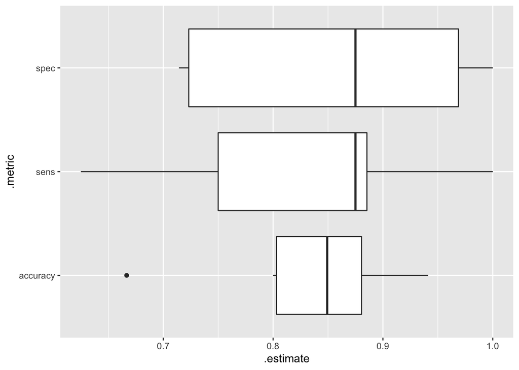

```r
spec <- workflow() %>% add_recipe(
  recipe(Group ~ ., data = data)) %>%
  add_model(decision_tree(mode = "classification") %>% set_engine("rpart"))
cv_results <- spec %>%
  fit_resamples(resamples, metrics = metrics)
cv_results %>%
  collect_metrics(summarize = FALSE) %>%
  ggplot(aes(x = .estimate, y = .metric)) + geom_boxplot()
```